[figure not shown]

# Clasification example for the University of Michigan

The purpose of this example is to demonstrate (on a first attempt) my ability to collect, work with, clean, and classify a set of text documents applied to a text problem in which the idea is to find the grade associated to different assays based on the lexical-syntactical structure of documents.

Example features:

1. All the code was implemented in Python 2.7 https://www.python.org/
2. The dataset used is part of a essay collection provide by the University of Michigan (econ_a1) which contains 300 Word documents, each one with a label from 1 to 5 that represent the score assigned to that document.
3. The Python packages required to run the programs are the following:
   - Jupyter notebook (Python interactive prompt) http://jupyter.org/index.html
   - PyWin32 (pre-processing Word documents) https://pypi.python.org/pypi/pywin32
   - Numpy (classification) http://www.numpy.org/
   - Scikit-learn (classification) http://scikit-learn.org/stable/
   - NLTK (NLP techniques) https://www.nltk.org/
   - CLips pattern (NLP techniques) https://www.clips.uantwerpen.be/pattern
   - Matplotlib (visualization) https://matplotlib.org/
   - WordCloud (visualization) https://pypi.python.org/pypi/wordcloud

## Pre-processing

The first step performed to classify the essays is to clean and transform the Word documents. The following shows how to achieve this task:

- Collect the list of the Word documents contained in the dataset.

```python
from os import listdir
from os.path import isfile, join
FILEPATH  = "C:/Users/EstebanCj/Desktop/michigan/econ_a1/essays/"
fileNames = [f for f in listdir(FILEPATH) if isfile(join(FILEPATH, f))]
#First 10 files in the list
print fileNames[:10]
```

```
['econ_a1_essay1.docx', 'econ_a1_essay10.docx', 'econ_a1_essay100.docx', 'econ_a1_essay101.docx', 'econ_a1_essay102.docx', 'econ_a1_essay103.docx', 'econ_a1_essay104.docx', 'econ_a1_essay105.docx', 'econ_a1_essay106.docx', 'econ_a1_essay107.docx']
```

- Obtain the scores (classification labels) associated to each Word document

```python
import json
FILEPATH2 = "C:/Users/EstebanCj/Desktop/michigan/econ_a1/labels_econ_a1.json"
jsonFile=open(FILEPATH2)
jsonData = json.load(jsonFile)
jsonFile.close()
#First 10 files in the dictionary
print {k: jsonData[k] for k in jsonData.keys()[:10]}
```

```
{u'econ_a1_essay44.docx': 4, u'econ_a1_essay68.docx': 4, u'econ_a1_essay165.docx': 2, u'econ_a1_essay21.docx': 2, u'econ_a1_essay225.docx': 4, u'econ_a1_essay81.docx': 3, u'econ_a1_essay116.docx': 4, u'econ_a1_essay229.docx': 1, u'econ_a1_essay97.docx': 3, u'econ_a1_essay241.docx': 2}
```

- Generate a single preprocessed file that contains the texts of all Word documents.

```python
import codecs
import re
import win32com.client
textList=[]
for document in fileNames:
    doc  = win32com.client.GetObject(FILEPATH+document)
    text = doc.Range().Text
    text = text.replace('\n',' ')
    text = re.sub('[^A-Za-z0-9 ]+', '',text.lower())
    textList.append((document,text,jsonData[document]))
FILEPATH3 = "C:/Users/EstebanCj/Desktop/michigan/econ_a1/dataset.txt"
#First element in the preprocessed text file
print textList[0]
with codecs.open(FILEPATH3,"w","UTF-8") as file:
    for element in textList:
        # separator element used: "@-?@"
        file.write(element[0]+"@-?@"+str(element[2])+"@-?@"+element[1]+"\n")
```

```
('econ_a1_essay1.docx', u'the theories used to construct economic models are in some cases also useful for describing how biological systems work this diagram highlights the principle of comparative advantage and the benefits of trade and shows how each can be seen in economic and biological markets…
```

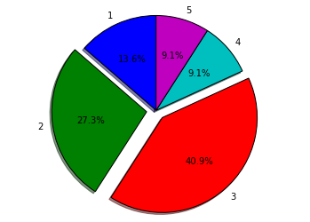

```python
%matplotlib inline
import matplotlib.pyplot as plt

scores=[]
for score in range(1,6):
  scores.append(sum(1 for x in jsonData.values() if x==score))

labels = '1', '2', '3', '4', '5'
sizes = [15, 30, 45, 10,10]
explode = (0, 0.1, 0.1, 0, 0)  # only "explode" the 2nd slice (i.e. 'Hogs')

fig1, ax1 = plt.subplots()
ax1.pie(sizes, explode=explode, labels=labels, autopct='%1.1f%%',
        shadow=True, startangle=90)
ax1.axis('equal')  # Equal aspect ratio ensures that pie is drawn as a circle.

plt.show()
```

- Plot a word cloud that help us to see the main topics related to the dataset

[figure not shown]

```python
from wordcloud import WordCloud, STOPWORDS
stopwords = set(STOPWORDS)
featuresWordCloud='\t'.join([x[1]  for x in textList])
wordcloud = WordCloud(
        background_color='white',
        stopwords=stopwords,
        max_words=200,
        max_font_size=40,
        scale=3,
        random_state=1).generate(str(featuresWordCloud))
fig = plt.figure(1, figsize=(12, 12))
plt.axis('off')
plt.imshow(wordcloud)
plt.show()
```

## Feature set

- Obtain the Part of speech Tags (PoS tags) associated to each text document.

```python
from pattern.en import parse
PoSTagList=[]
FILEPATH3 = "C:/Users/EstebanCj/Desktop/michigan/econ_a1/dataset.txt"
with codecs.open(FILEPATH3,"r","utf-8") as file:
    for line in file:
      elementList=line.split("@-?@")
      elementsParser=parse(elementList[2])
      PoSTags=[]
      for PoSTag in elementsParser.split(" "):
         elements=PoSTag.split("/")
         PoSTags.append(elements[1])
      PoSTagList.append(PoSTags)
#Part of Speech tags of  econ_a1_essay1.docx
print PoSTagList[0]
```

```
[u'DT', u'NNS', u'VBD', u'TO', u'VB', u'JJ', u'NNS', u'VBP', u'IN', u'DT', u'NNS', u'RB', u'JJ', u'IN', u'VBG', u'WRB', u'JJ', u'NNS', u'NN', u'DT', u'NN', u'NNS', u'DT', u'NN', u'IN', u'JJ', u'NN', u'CC', u'DT', u'NNS', u'IN', u'NN', u'CC', u'VBZ', u'WRB', u'DT', u'MD', u'VB', u'VBN', u'IN', u'JJ',…
```

- Transform the Part of speech Tags to 5-grams for each text document

```python
from nltk.util import ngrams
NgramList=[]
for posTags in PoSTagList:
    nGrams=ngrams(posTags,5)
    NgramList.append([' '.join(e for e in nGram) for nGram in nGrams])
#Part of Speech bigrams of econ_a1_essay1.docx
print NgramList[0]
```

```
[u'DT NNS VBD TO VB', u'NNS VBD TO VB JJ', u'VBD TO VB JJ NNS', u'TO VB JJ NNS VBP', u'VB JJ NNS VBP IN', u'JJ NNS VBP IN DT', u'NNS VBP IN DT NNS', u'VBP IN DT NNS RB', u'IN DT NNS RB JJ', u'DT NNS RB JJ IN', u'NNS RB JJ IN VBG', u'RB JJ IN VBG WRB', u'JJ IN VBG WRB JJ', u'IN VBG WRB JJ NNS', u'VBG…
```

- Obtain the 5-grams frequency of occurrence considering all text documents in order to obtain a feature set.

```python
import operator
nGramFeatureSet={}
for elements in NgramList:
  for ngram in elements:
     if ngram in nGramFeatureSet:
        nGramFeatureSet[ngram]=nGramFeatureSet[ngram]+1
     else:
        nGramFeatureSet[ngram]=1
nGramFeatureSetSort = sorted(nGramFeatureSet.items(),
                                 key=operator.itemgetter(1),
                                 reverse=True)
#50 most frequent Part of Speech bigrams in all documents
print nGramFeatureSetSort[:50]
```

```
[(u'VBZ DT JJ NN IN', 1144), (u'DT JJ NN IN NN', 576), (u'DT JJ NN IN VBG', 493), (u'NN VBZ DT JJ NN', 469), (u'NN IN DT JJ NN', 453), (u'DT JJ NN IN DT', 332), (u'NN IN DT NN IN', 319), (u'IN DT NN IN NN', 311), (u'IN DT JJ NN NN', 299), (u'DT VBZ DT JJ NN', 297), (u'NN DT VBZ DT JJ', 287), (u'IN D…
```

- Generate a feature set file considering the frequency of occurence of Part of Speech 5-grams in all text documents.

```python
FILEPATH4 = "C:/Users/EstebanCj/Desktop/michigan/econ_a1/featureSet.txt"
with codecs.open(FILEPATH4,"w","UTF-8") as file:
    for element in nGramFeatureSetSort:
        file.write(element[0]+"@-?@"+str(element[1])+"\n")
```

## Vector representation

The next step to predict the essays scores is to transform each document to a vector representation using the bag of words model. The following steps show how to obtain these vectors:

```python
import codecs
vectorFeatures=[]
FILEPATH5 = "C:/Users/EstebanCj/Desktop/michigan/econ_a1/featureSet.txt"
counter=0
numberFeatures= 200
with codecs.open(FILEPATH5,"r","UTF-8") as file:
    for line in file:
       counter=counter+1
       if counter <= numberFeatures:
            elementsList=line.split("@-?@")
            vectorFeatures.append(elementsList[0])
       else:
            break
#Textual features selected for the vector representation
print vectorFeatures
```

```
[u'VBZ DT JJ NN IN', u'DT JJ NN IN NN', u'DT JJ NN IN VBG', u'NN VBZ DT JJ NN', u'NN IN DT JJ NN', u'DT JJ NN IN DT', u'NN IN DT NN IN', u'IN DT NN IN NN', u'IN DT JJ NN NN', u'DT VBZ DT JJ NN', u'NN DT VBZ DT JJ', u'IN DT JJ NN IN', u'NN NN VBZ DT JJ', u'DT JJ NN IN NNS', u'IN DT NN IN DT', u'NN IN…
```

- Transform each text (in dataset.txt) to a vector representation searching for the frequency of occurrence of the selected features.

```python
from nltk.util import ngrams
from pattern.en import parse
import codecs
FILEPATH6 = "C:/Users/EstebanCj/Desktop/michigan/econ_a1/dataset.txt"
vectorList=[]
sentimentTags=[]
with codecs.open(FILEPATH6,"r","utf-8") as file:
    for line in file:
       vector=[]
       elementList=line.split("@-?@")
       sentimentTags.append(elementList[1])
       elementsParser=parse(elementList[2])
       PoSTags=[]
       for PoSTag in elementsParser.split(" "):
          elements=PoSTag.split("/")
          PoSTags.append(elements[1])
       nGrams=ngrams(PoSTags,5)
       nGramsList=[' '.join(e for e in nGram) for nGram in nGrams]
       for feature in vectorFeatures:
            vector.append(nGramsList.count(feature))
       vectorList.append(vector)
# Vector representation of econ_a1_essay1.docx
print "vector"
print vectorList[0]
print "score associated"
print sentimentTags[0]
```

```
vector
[2, 2, 1, 0, 3, 1, 0, 0, 1, 1, 1, 1, 0, 0, 0, 3, 0, 1, 0, 0, 0, 0, 3, 0, 0, 1, 0, 0, 0, 1, 1, 2, 0, 1, 0, 0, 1, 0, 1, 0, 1, 0, 0, 2, 0, 0, 1, 0, 0, 0, 0, 1, 0, 0, 0, 0, 1, 0, 0, 0, 1, 0, 1, 0, 0, 1, 0, 1, 2, 0, 0, 1, 0, 1, 1, 0, 1, 0, 0, 0, 0, 1, 0, 0, 0, 2, 1, 2, 0, 0, 1, 1, 1, 0, 0, 0, 0, 0, 0, 1,…
score associated
4
```

## Classification process

In the next step, the vectors previously created are used to construct predictive models using different supervised learning algorithms. The following steps show how to obtain these models:

- Separate the dataset into a train a test subsets.

```python
X_train= vectorList[0:200]
y_train= sentimentTags[0:200]
X_test = vectorList[201:]
y_test =sentimentTags[201:]
```

- Create different classification models using the training vectors.

```python
#Support Vector machine classifier(SVM)
from sklearn import svm
from sklearn.svm import SVC
# SVC with polynomial (degree 3) kernel
C = 1.0
clf= poly_svc = svm.SVC(kernel='poly', degree=3, C=C)
#training phase (model construction)
clf.fit(X_train, y_train)
```

```
SVC(C=1.0, cache_size=200, class_weight=None, coef0=0.0,
  decision_function_shape='ovr', degree=3, gamma='auto', kernel='poly',
  max_iter=-1, probability=False, random_state=None, shrinking=True,
  tol=0.001, verbose=False)
```

```python
#Naive Bayes classifier
from sklearn.naive_bayes import MultinomialNB
#training phase (model construction)
clf2 = MultinomialNB().fit(X_train, y_train)
```

```python
#Logistic Regression classifier
from sklearn import linear_model
clf3 = linear_model.LogisticRegression(C=1e5)
clf3.fit(X_train, y_train)
```

```
LogisticRegression(C=100000.0, class_weight=None, dual=False,
          fit_intercept=True, intercept_scaling=1, max_iter=100,
          multi_class='ovr', n_jobs=1, penalty='l2', random_state=None,
          solver='liblinear', tol=0.0001, verbose=0, warm_start=False)
```

- Using the previously created models evaluate the vectors of the test dataset.

```python
#test the model considering the frequency vectors for the SVM classifier
testResults=[]
for vector in X_test:
    testResults.append(clf.predict([vector])[0])
#Predicted scores of the tes dataset
print "SVM classifier results"
print testResults
#test the model considering the frequency vectors for the Naive Bayes classifier
testResults2=[]
for vector in X_test:
    testResults2.append(clf2.predict([vector])[0])
#Predicted scores of the tes dataset
print "Naive Bayes classifier results"
print testResults2
#test the model considering the frequency vectors for the logistic regression classifier
testResults3=[]
for vector in X_test:
    testResults3.append(clf3.predict([vector])[0])
print "logistic regression classifier results"
print testResults3
print "Correct values of the test datase"
print y_test
```

```
SVM classifier results
[u'3', u'3', u'3', u'3', u'3', u'4', u'3', u'3', u'3', u'4', u'3', u'3', u'3', u'3', u'3', u'3', u'4', u'3', u'3', u'3', u'3', u'3', u'3', u'3', u'3', u'3', u'3', u'3', u'3', u'3', u'3', u'3', u'4', u'4', u'3', u'3', u'4', u'3', u'3', u'4', u'3', u'3', u'3', u'3', u'3', u'3', u'3', u'3', u'4', u'3',…
Naive Bayes classifier results
[u'2', u'2', u'3', u'4', u'2', u'2', u'3', u'3', u'5', u'4', u'4', u'3', u'4', u'2', u'3', u'3', u'4', u'2', u'3', u'3', u'3', u'4', u'3', u'3', u'3', u'3', u'3', u'1', u'3', u'3', u'3', u'3', u'4', u'4', u'2', u'3', u'4', u'4', u'4', u'2', u'4', u'5', u'3', u'4', u'4', u'3', u'5', u'5', u'4', u'3',…
logistic regression classifier results
[u'3', u'3', u'2', u'4', u'4', u'4', u'3', u'3', u'3', u'4', u'3', u'4', u'4', u'4', u'3', u'4', u'4', u'3', u'4', u'3', u'3', u'2', u'3', u'3', u'3', u'2', u'5', u'4', u'3', u'3', u'1', u'3', u'4', u'2', u'3', u'4', u'4', u'4', u'3', u'2', u'3', u'5', u'3', u'2', u'4', u'5', u'5', u'5', u'5', u'2',…
Correct values of the test datase
[u'3', u'4', u'3', u'4', u'3', u'5', u'2', u'3', u'3', u'4', u'1', u'4', u'3', u'4', u'4', u'3', u'4', u'3', u'5', u'3', u'3', u'3', u'3', u'3', u'3', u'3', u'3', u'4', u'4', u'4', u'4', u'1', u'3', u'5', u'4', u'3', u'4', u'3', u'4', u'4', u'4', u'4', u'2', u'3', u'4', u'2', u'4', u'3', u'5', u'3',…
```

```python
from sklearn.metrics import f1_score
from sklearn.metrics import precision_score
print "SVM model"
print "Model f1 measure: "+str(f1_score(testResults,y_test, average='micro'))
print "Model micro presicion: "+str(precision_score(y_test,testResults, average='micro'))
print "Model macro presicion: "+str(precision_score(y_test,testResults, average='macro'))

print "Naive Bayes Model"
print "Model f1 measure: "+str(f1_score(testResults2,y_test, average='micro'))
print "Model micro presicion: "+str(precision_score(y_test,testResults2, average='micro'))
print "Model macro presicion: "+str(precision_score(y_test,testResults2, average='macro'))

print "logistic regression Model"
print "Model f1 measure: "+str(f1_score(testResults3,y_test, average='micro'))
print "Model micro presicion: "+str(precision_score(y_test,testResults3, average='micro'))
print "Model macro presicion: "+str(precision_score(y_test,testResults3, average='macro'))
```

```
SVM model
Model f1 measure: 0.45454545454545453
Model micro presicion: 0.45454545454545453
Model macro presicion: 0.19710407239819006
Naive Bayes Model
Model f1 measure: 0.3333333333333333
Model micro presicion: 0.3333333333333333
Model macro presicion: 0.18375
logistic regression Model
Model f1 measure: 0.3434343434343434
Model micro presicion: 0.3434343434343434
Model macro presicion: 0.2122335519573683
```